# 🐍 Practice n°2: exploratory data analysis

### `user`

#### Distribution

```python
df_user_degree = df.loc[:, ["user", "user_degree"]].drop_duplicates()
df_user_degree
```

df_user_degree = df.loc[:, ["user", "user_degree"]].drop_duplicates() df_user_degree

|  | user | user_degree |
| --- | --- | --- |
| 0 | blutt59 | 300 |
| 300 | VAYankee | 23 |
| 323 | garretjax | 7 |
| 330 | randolphjj | 10 |
| 340 | Leafs93 | 56 |
| ... | ... | ... |
| 199995 | kuleko | 1 |
| 199996 | Andressantis | 1 |
| 199997 | DesmondLangham | 1 |
| 199998 | thedees | 1 |
| 199999 | apeters | 1 |

11251 rows × 2 columns

```python
(
    (df_user_degree.user_degree)
    .value_counts()
    .reset_index()
    .plot.scatter(  # LINE TO BE REMOVED FOR STUDENTS
        x="user_degree",  # LINE TO BE REMOVED FOR STUDENTS
        y="count",  # LINE TO BE REMOVED FOR STUDENTS
        marker=".",  # LINE TO BE REMOVED FOR STUDENTS
    )  # LINE TO BE REMOVED FOR STUDENTS
)
```

( (df_user_degree.user_degree) .value_counts() .reset_index() .plot.scatter( # LINE TO BE REMOVED FOR STUDENTS x="user_degree", # LINE TO BE REMOVED FOR STUDENTS y="count", # LINE TO BE REMOVED FOR STUDENTS marker=".", # LINE TO BE REMOVED FOR STUDENTS ) # LINE TO BE REMOVED FOR STUDENTS )

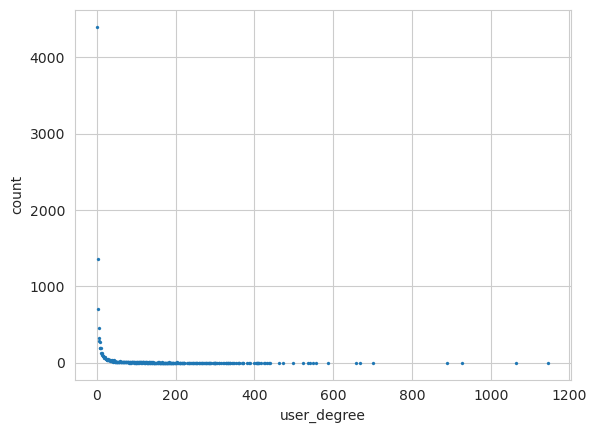

```python
(
    (df_user_degree.user_degree)
    .value_counts()
    .reset_index()
    .plot.scatter(  # LINE TO BE REMOVED FOR STUDENTS
        x="user_degree",  # LINE TO BE REMOVED FOR STUDENTS
        y="count",  # LINE TO BE REMOVED FOR STUDENTS
        loglog=True,  # LINE TO BE REMOVED FOR STUDENTS
        marker=".",  # LINE TO BE REMOVED FOR STUDENTS
    )  # LINE TO BE REMOVED FOR STUDENTS
)
```

( (df_user_degree.user_degree) .value_counts() .reset_index() .plot.scatter( # LINE TO BE REMOVED FOR STUDENTS x="user_degree", # LINE TO BE REMOVED FOR STUDENTS y="count", # LINE TO BE REMOVED FOR STUDENTS loglog=True, # LINE TO BE REMOVED FOR STUDENTS marker=".", # LINE TO BE REMOVED FOR STUDENTS ) # LINE TO BE REMOVED FOR STUDENTS )

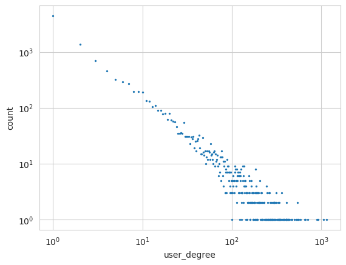

```python
plot_rank_size(df_user_degree.user_degree)
```

plot_rank_size(df_user_degree.user_degree)

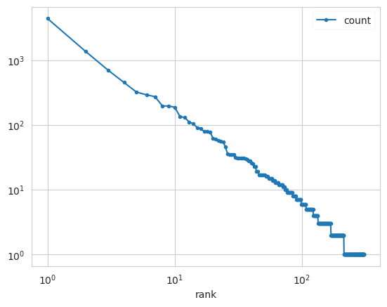

#### Relationship with target

```python
sns.displot(
    df, x="user_degree", hue="is_good"
)
```

sns.displot( df, x="user_degree", hue="is_good" )

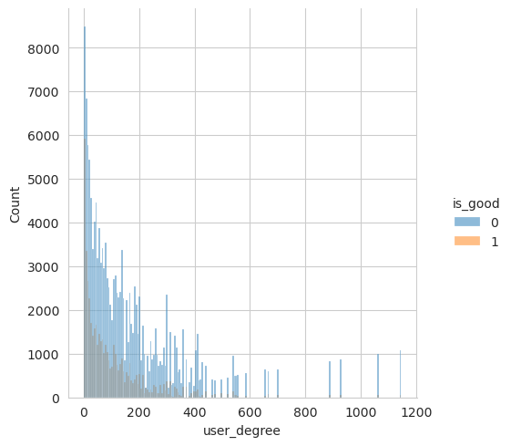

```python
sns.displot(
    df,
    x="user_degree",
    hue="is_good",
    log_scale=True,
)
```

sns.displot( df, x="user_degree", hue="is_good", log_scale=True, )

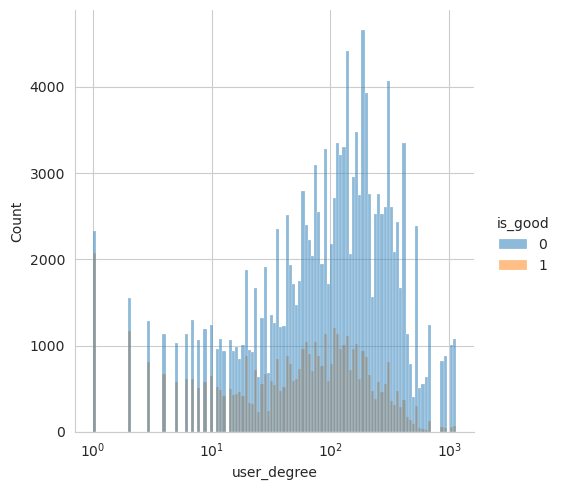

```python
sns.displot(
    df,
    x="user_degree",
    hue="is_good",
    log_scale=True,
    multiple="fill",
)
```

sns.displot( df, x="user_degree", hue="is_good", log_scale=True, multiple="fill", )

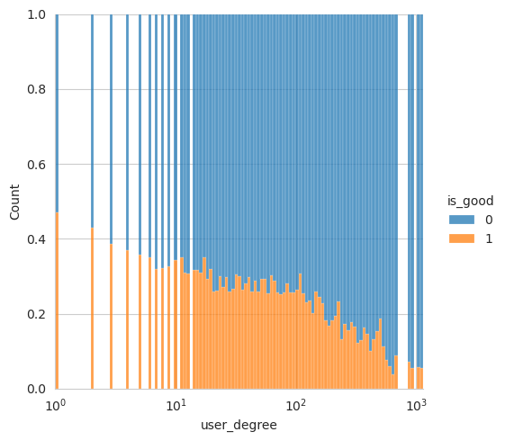

## Text variable

Using the [`pd.Series.str`](https://pandas.pydata.org/docs/reference/api/pandas.Series.str.html) API

### Text length

#### Distribution

Is it a Power law distribution ?

```python
(df.text_length).plot.hist(bins=200)  # LINE TO BE REMOVED FOR STUDENTS
```

(df.text_length).plot.hist(bins=200) # LINE TO BE REMOVED FOR STUDENTS

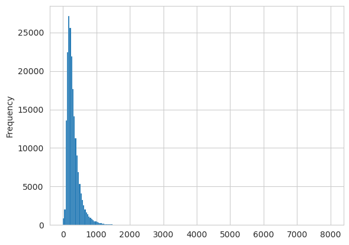

```python
((df.text_length).plot.hist(bins=200, logy=True))
```

((df.text_length).plot.hist(bins=200, logy=True))

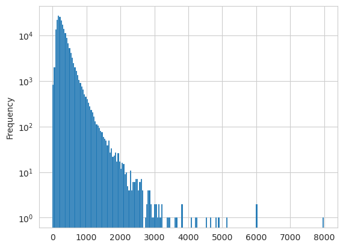

#### Relationship with the target

```python
sns.displot(df, x="text_length")
```

sns.displot(df, x="text_length")

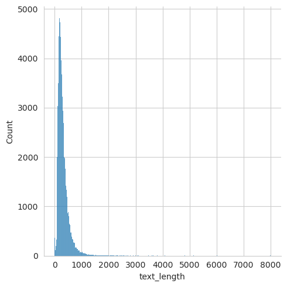

```python
sns.displot(
    df,
    x="text_length",
    hue="is_good",
)
```

sns.displot( df, x="text_length", hue="is_good", )

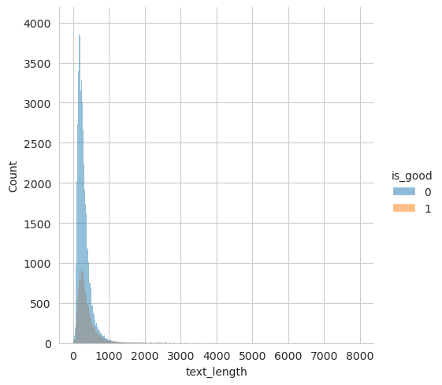

```python
sns.displot(
    df.loc[lambda df: df.text_length < 1500],
    x="text_length",
    hue="is_good",
)
```

sns.displot( df.loc[lambda df: df.text_length < 1500], x="text_length", hue="is_good", )

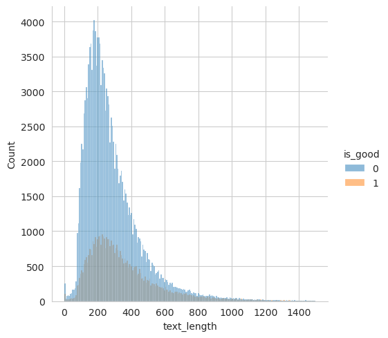

```python
sns.displot(
    df.loc[lambda df: df.text_length < 1500],
    x="text_length",
    hue="is_good",
    multiple="fill",
)
```

sns.displot( df.loc[lambda df: df.text_length < 1500], x="text_length", hue="is_good", multiple="fill", )

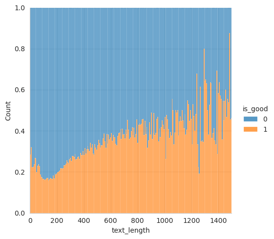

### Words associated to positive & negative reviews (optional)

```python
(
    (df)
    .head(100000)
    .assign(
        tokenized_text=lambda df: (df.text)
        .str.lower()
        .str.replace(r"[^a-z]", " ")
        .str.replace(r" +", " ")
        .str.split(" ")
    )
    .loc[:, ["rating", "tokenized_text"]]
    .explode("tokenized_text")
    .loc[lambda df: df.tokenized_text != ""]
    .groupby("tokenized_text", as_index=False)
    .agg(["mean", "count"])
    .reset_index()
    .sort_values(by=("rating", "count"), ascending=False)
    .head(200)
    .style.background_gradient(cmap="RdYlGn")
)
```

( (df) .head(100000) .assign( tokenized_text=lambda df: (df.text) .str.lower() .str.replace(r"[^a-z]", " ") .str.replace(r" +", " ") .str.split(" ") ) .loc[:, ["rating", "tokenized_text"]] .explode("tokenized_text") .loc[lambda df: df.tokenized_text != ""] .groupby("tokenized_text", as_index=False) .agg(["mean", "count"]) .reset_index() .sort_values(by=("rating", "count"), ascending=False) .head(200) .style.background_gradient(cmap="RdYlGn") )

|  | index | tokenized_text | rating mean | rating count |
| --- | --- | --- | --- | --- |
| 23275 | 23275 | a | 13.586334 | 241381 |
| 28030 | 28030 | and | 13.721123 | 212352 |
| 148797 | 148797 | the | 13.713381 | 169186 |
| 161860 | 161860 | with | 13.563324 | 156450 |
| 112885 | 112885 | of | 13.675712 | 133776 |
| 90940 | 90940 | is | 13.447157 | 109834 |
| 150780 | 150780 | to | 13.522130 | 58857 |
| 89101 | 89101 | in | 13.507647 | 49298 |
| 97612 | 97612 | light | 12.859438 | 47296 |
| 82869 | 82869 | head. | 13.214893 | 47270 |
| 29776 | 29776 | aroma | 13.304910 | 46335 |
| 138634 | 138634 | some | 13.531472 | 44992 |
| 44510 | 44510 | but | 13.407445 | 44109 |
| 149542 | 149542 | this | 13.633697 | 42211 |
| 157022 | 157022 | very | 13.926570 | 39943 |
| 88160 | 88160 | i | 13.446812 | 39135 |
| 145181 | 145181 | sweet | 13.353797 | 37920 |
| 72292 | 72292 | flavor | 13.438029 | 32943 |
| 91152 | 91152 | it | 13.442805 | 32057 |
| 111067 | 111067 | not | 12.693228 | 30922 |
| 160838 | 160838 | white | 12.765617 | 30655 |
| 148708 | 148708 | that | 13.628333 | 30191 |
| 113892 | 113892 | on | 13.704276 | 29913 |
| 31158 | 31158 | at | 13.454488 | 28498 |
| 58150 | 58150 | dark | 14.380695 | 27723 |
| 109609 | 109609 | nice | 14.524580 | 26078 |
| 122501 | 122501 | pours | 13.746651 | 25230 |
| 103581 | 103581 | medium | 13.422387 | 25086 |
| 30626 | 30626 | as | 13.803236 | 24471 |
| 100764 | 100764 | malt | 13.348653 | 24196 |

[output cut: 170 more lines]

### Word frequencies (optional)

Compute the frequency of the most used words in the texts

Methods you'll need:

- [`pd.Series.str.len`](https://pandas.pydata.org/docs/reference/api/pandas.Series.str.len.html)
- [`pd.Series.str.split`](https://pandas.pydata.org/docs/reference/api/pandas.Series.str.split.html)
- [`pd.Series.explode`](https://pandas.pydata.org/docs/reference/api/pandas.Series.explode.html)
- [`pd.Series.value_counts`](https://pandas.pydata.org/docs/reference/api/pandas.Series.value_counts.html)
- [`pd.Series.head`](https://pandas.pydata.org/docs/reference/api/pandas.Series.head.html)

Bonus: plot an histogram of the values, with log values, using:

- [`pd.Series.plot.hist`](https://pandas.pydata.org/docs/reference/api/pandas.Series.plot.bar.html)

Is it a Power law distribution ?

```python
df_word_frequencies = (
    (df.text)
    .str.lower()
    .str.replace(r"[^a-z\ ]", "")
    .str.replace(r"\ +", " ")
    .str.split(" ")  # LINE TO BE REMOVED FOR STUDENTS
    .explode()
    .loc[lambda x: x != ""]
    .value_counts(normalize=True)
    .rename("word_frequency")
    .rename_axis(index="word")
    .reset_index()
    .assign(rank=lambda df: range(1, 1 + df.shape[0]))
)
df_word_frequencies
```

df_word_frequencies = ( (df.text) .str.lower() .str.replace(r"[^a-z\ ]", "") .str.replace(r"\ +", " ") .str.split(" ") # LINE TO BE REMOVED FOR STUDENTS .explode() .loc[lambda x: x != ""] .value_counts(normalize=True) .rename("word_frequency") .rename_axis(index="word") .reset_index() .assign(rank=lambda df: range(1, 1 + df.shape[0])) ) df_word_frequencies

|  | word | word_frequency | rank |
| --- | --- | --- | --- |
| 0 | a | 4.38e-02 | 1 |
| 1 | and | 3.63e-02 | 2 |
| 2 | the | 3.13e-02 | 3 |
| 3 | with | 2.67e-02 | 4 |
| 4 | of | 2.35e-02 | 5 |
| ... | ... | ... | ... |
| 269396 | vapeur-like | 9.51e-08 | 269397 |
| 269397 | tongue-cleaning. | 9.51e-08 | 269398 |
| 269398 | sidra | 9.51e-08 | 269399 |
| 269399 | virtuous | 9.51e-08 | 269400 |
| 269400 | fruit-oriented | 9.51e-08 | 269401 |

269401 rows × 3 columns

```python
df_word_frequencies.head(10000).plot(x="rank", y="word_frequency", marker=".")
```

df_word_frequencies.head(10000).plot(x="rank", y="word_frequency", marker=".")

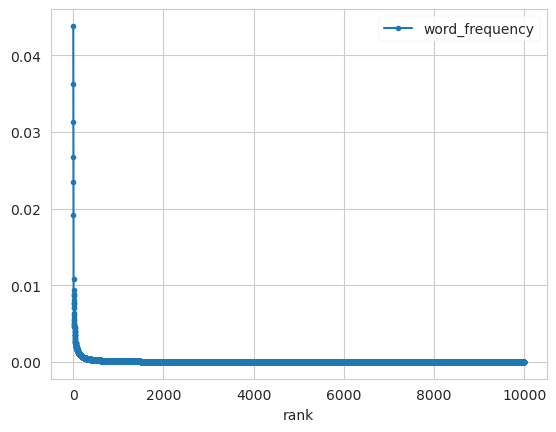

```python
df_word_frequencies.head(10000).plot(
    x="rank", y="word_frequency", loglog=True, marker="."
)
```

df_word_frequencies.head(10000).plot( x="rank", y="word_frequency", loglog=True, marker="." )

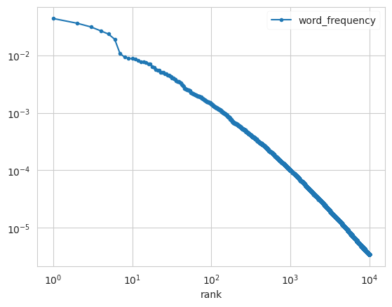

## And if it's a regression ?

We show those plot examples to explain what would be an exploratory data analysis for a regression problem.

### Continuous variable

```python
sns.displot(
    df.loc[lambda df: df.alcohol < 20],
    x="alcohol",
    hue="rating",
    multiple="fill",
    palette="RdYlGn",
    bins=20,
)
```

sns.displot( df.loc[lambda df: df.alcohol < 20], x="alcohol", hue="rating", multiple="fill", palette="RdYlGn", bins=20, )

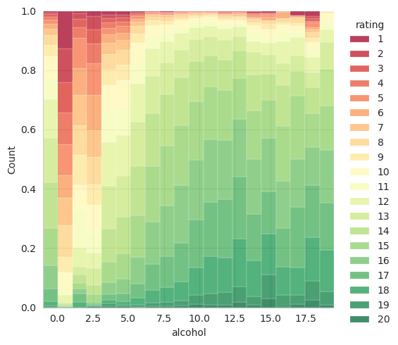

```python
sns.displot(
    df.loc[lambda df: df.alcohol < 20],
    x="alcohol",
    y="rating",
    bins=20,
)
```

sns.displot( df.loc[lambda df: df.alcohol < 20], x="alcohol", y="rating", bins=20, )

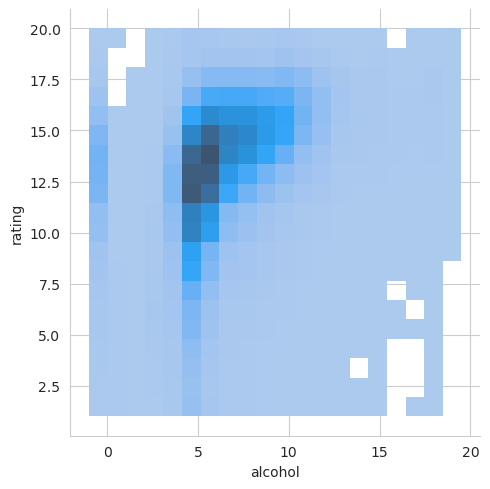

### Categorical variable

```python
sns.displot(
    df,
    x="rating_appearance",
    discrete=True,
    hue="rating",
    multiple="stack",
    palette="RdYlGn",
)
```

sns.displot( df, x="rating_appearance", discrete=True, hue="rating", multiple="stack", palette="RdYlGn", )

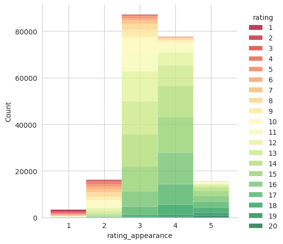

```python
sns.displot(
    df,
    x="rating_appearance",
    discrete=True,
    hue="rating",
    multiple="fill",
    palette="RdYlGn",
)
```

sns.displot( df, x="rating_appearance", discrete=True, hue="rating", multiple="fill", palette="RdYlGn", )

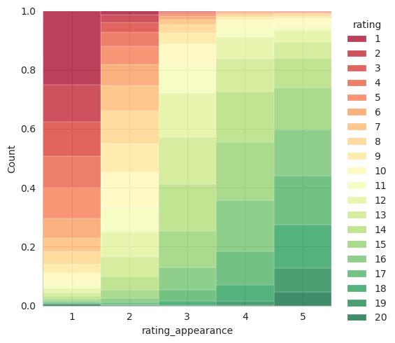

```python
sns.violinplot(
    df,
    x="rating_appearance",
    y="rating",
)
```

sns.violinplot( df, x="rating_appearance", y="rating", )

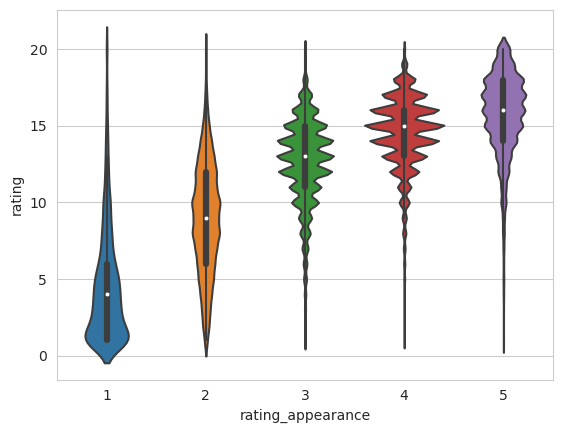